# Plotting with matplotlib

## Let's plot!

So what does this look like in practice? Here's a simple example of managing a two-panel figure in the python style:

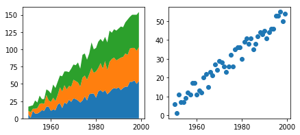

```python
fig, (ax1, ax2) = plt.subplots(1,2, figsize=(7, 3)) #create a figure with 2 axes objects (subplots)
ax1.stackplot(yrs, rng + rnd) #call a method belonging to ax1
ax2.scatter(yrs, (rng + rnd)[0]) #call a method belonging to ax2
```

That's the pythonic way. How about the matlab way?

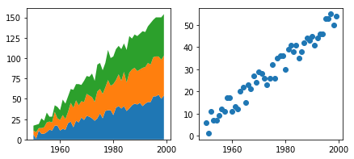

```python
fig, (ax1, ax2) = plt.subplots(1,2, figsize=(7, 3))
plt.sca(ax1) # sca = set current axis (it's useful cousin is gca 'get current axis')
plt.stackplot(yrs, rng + rnd) #system method stackplot works on the active axes object (ax1)
plt.sca(ax2)
plt.scatter(yrs, (rng + rnd)[0])
```

Both ways produce the same result. For more complex plotting, I think the pythonic style is generally preferable, but honestly I'm pretty new to matplotlib so who knows.

### Adding the details: **kwargs and set_ methods

To build complete, detailed plots is a little different in matplotlib from some other languages. Whereas in R or Matlab you might have a single plot function and you would supply information about the titles, axes, etc. with arguments to that function, in matplotlib you build the different parts of the plot with distinct functions. In the following example:

```
* the data are plotted by the stackplot() function
* the legend is created by the legend() function
* the axis labels are created by set_xlabel() and set_ylabel()
```

Each of these functions can take a large number of arguments to specify exactly how you want to make the structure in question. These arguments are generally of the form "size=12' and are referred to as keyword-args or *kwargs* in python annotation.

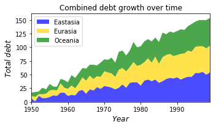

```python
fig, ax = plt.subplots(figsize=(5, 3))
ax.stackplot(yrs, rng + rnd, colors=["blue", "gold", "green"], labels=['Eastasia', 'Eurasia', 'Oceania'], alpha=0.7)
ax.set_title('Combined debt growth over time')
ax.legend(loc='upper left')
ax.set_ylabel('$Total$ $debt$', size=12)
ax.set_xlabel('$Year$', size=12)
ax.set_xlim(xmin=yrs[0], xmax=yrs[-1])
fig.tight_layout()
```

### Endless possibilities

So there's just an absolutely endless supply of matplotlib packages, methods, etc. to visualize data in any way you can think of (and a whole bunch you can't). I'm sure we will explore a lot of this in coding club. Hopefully this introduction will clear up some confusing things about matplotlib, and set you up with a basic understanding of how it does things. I really recommend taking a look at the [tutorial](https://realpython.com/python-matplotlib-guide/) I based this on, as it goes a little deeper and farther than I have here. I leave you with an example of a fairly complex figure from that tutorial:

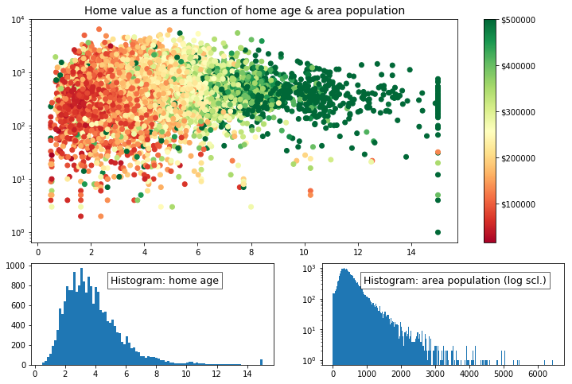

```python
# Load some data about California housing
from io import BytesIO
import tarfile
from urllib.request import urlopen

url = 'http://www.dcc.fc.up.pt/~ltorgo/Regression/cal_housing.tgz'
b = BytesIO(urlopen(url).read())
fpath = 'CaliforniaHousing/cal_housing.data'

with tarfile.open(mode='r', fileobj=b) as archive:
    housing = np.loadtxt(archive.extractfile(fpath), delimiter=',')

# Arrange the data to plot later
y = housing[:, -1]
pop, age = housing[:, [4, 7]].T


# Make a custom function for adding a titlebox
def add_titlebox(ax, text):
    ax.text(.55, .8, text,
        horizontalalignment='center',
        transform=ax.transAxes,
        bbox=dict(facecolor='white', alpha=0.6),
        fontsize=12.5)
    return

# use matplotlibs gridspec module to make subplots of unequal size
gridsize = (3, 2)
fig = plt.figure(figsize=(12, 8))
ax1 = plt.subplot2grid(gridsize, (0, 0), colspan=2, rowspan=2)
ax2 = plt.subplot2grid(gridsize, (2, 0))
ax3 = plt.subplot2grid(gridsize, (2, 1))

# Throw down some plots
ax1.set_title('Home value as a function of home age & area population',
              fontsize=14)
sctr = ax1.scatter(x=age, y=pop, c=y, cmap='RdYlGn')
plt.colorbar(sctr, ax=ax1, format='$%d')
ax1.set_yscale('log')
ax2.hist(age, bins='auto')
ax3.hist(pop, bins='auto', log=True)

add_titlebox(ax2, 'Histogram: home age')
add_titlebox(ax3, 'Histogram: area population (log scl.)')
```

#stadler #tutorial #matplotlib